# ROCK Never out of Date

[figure not shown]

### Project Background

Everyone has his own favourite singers and songs. Maybe within different period, preference will change. But classics will remain popular for certain reason. In this project, the secret of Rock will be revealed and the convey of emotion will be discussed.

The proportion of different genres for all songs:

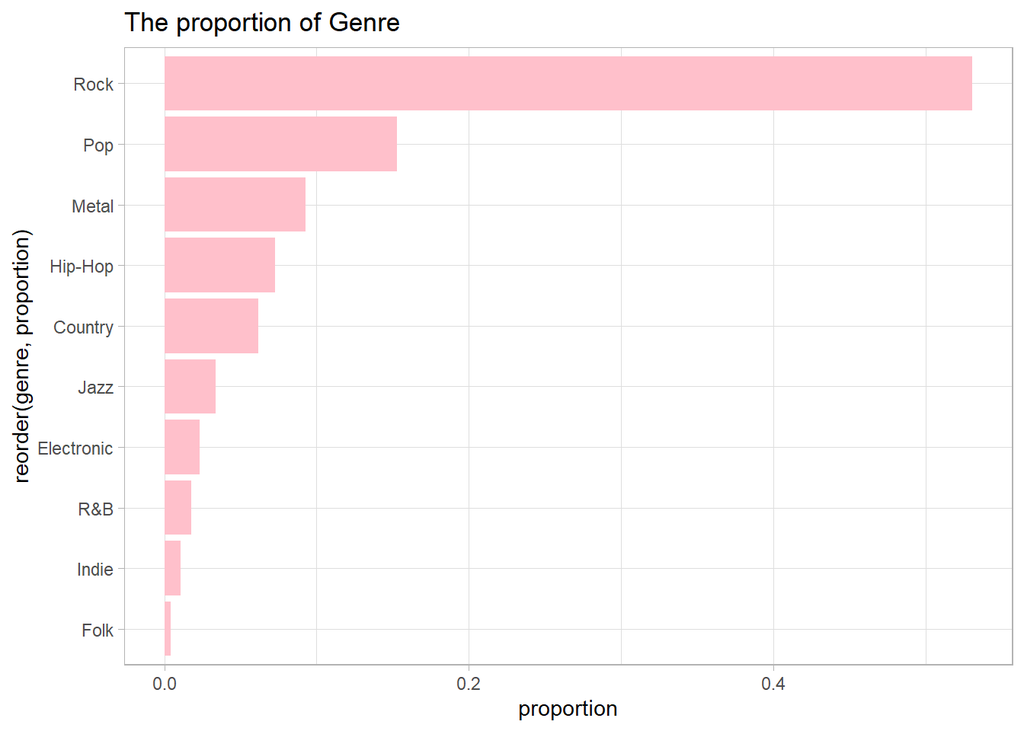

As is shown, for total number of songs, the proportion of Rock is the highest, which means there is more Rock songs than any other kind of genres. Next, let’s check the population of Rock during past 50 years.

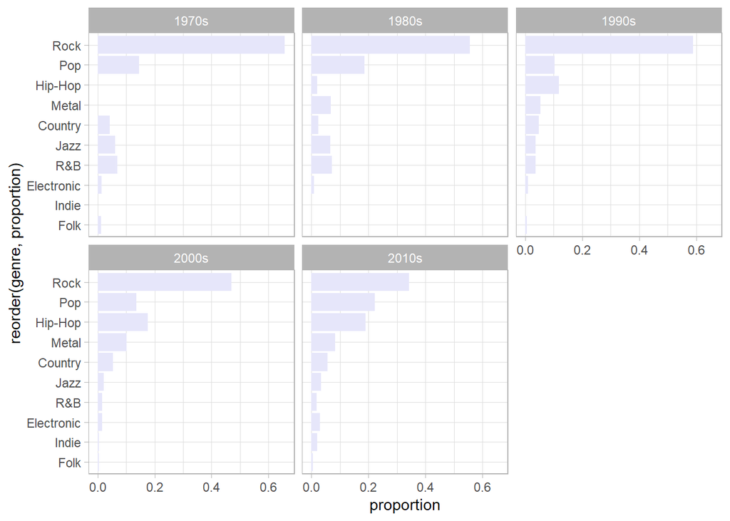

From the plots of proportion of genres during different periods, it is obvious that Rock music has been always the most popular genre since 1970s. Therefore, the difference in essence between Rock and other genres that leads to the popularity sounds attractive.

### Sentiment Analysis

As is known to all, an important function of music is to express mood. So it is important to figure out the differnece between Rock music and other genres in expressing mood that may influence the need of certain genre of music. Lyric is a good way to convey emotional information, for example, if the theme of a song is positive, the words in lyrics will contain happy, hope such positive words with high probability, instead of kill, death such negative words. Therefore, I will first have a general review of frequent used words in all kinds of genres to figure out whether Rock music behaves differently in conveying emotions compared to other genres.

**WordCloud of Rock**

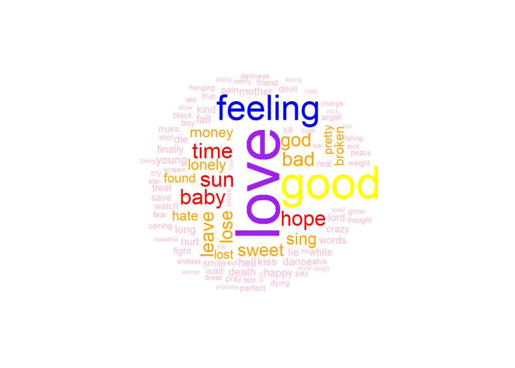

From the wordcloud plot, it can be seen that love feeling and good are the most frequent words used in Rock music. Besides, bad, lose, lonely and hate are often metioned in lyrics. So it could be inferred that Rock music can always be used to express positive and nagative emotions.

**WordCloud of Metal**

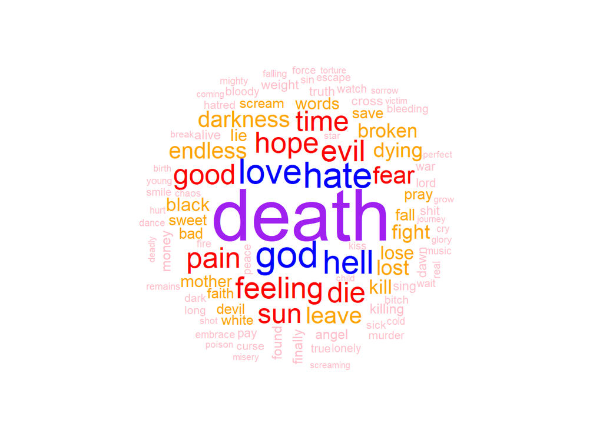

**WordCloud of Country**

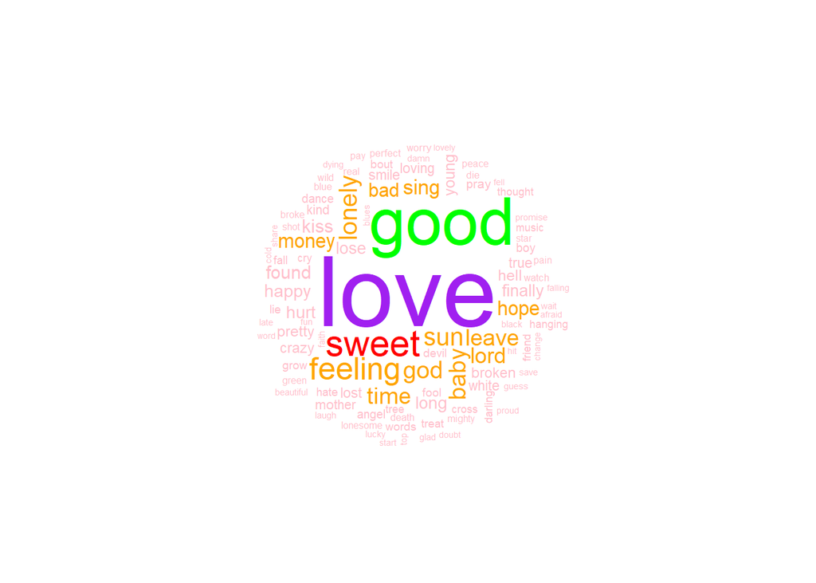

Due to the limit of space, the report only shows three genres’ wordclouds. But it is obvious that different kinds of genres always use different kinds of words highly associated with some kinds of emotions. Next, I will show a more detailed version of frequent used words of all genres.

**TOP 10 frequentist used words of all gernes**:

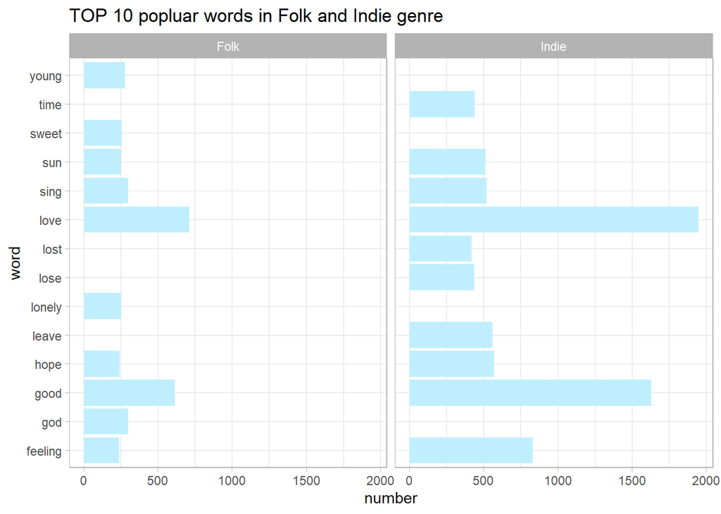

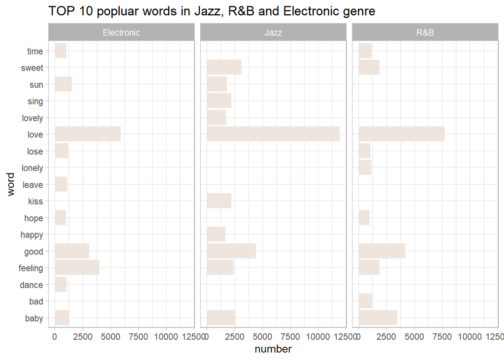

[figure not shown]

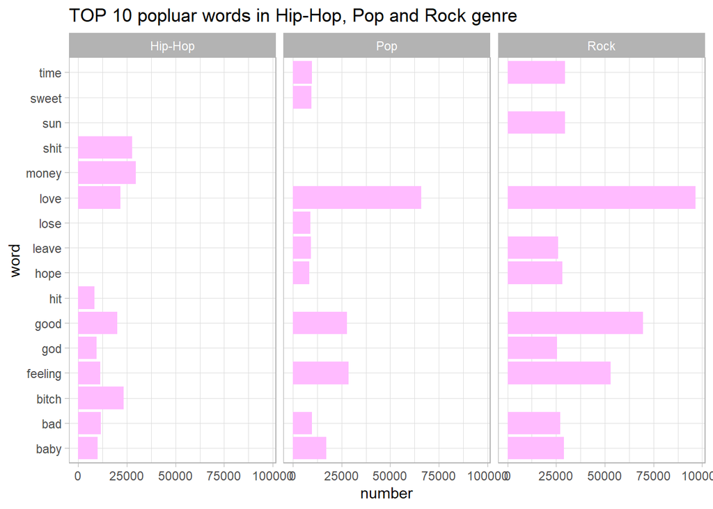

According to the plots above, some kinds of genres have similar kinds of emotions, but there are still many genres using other emotional expression. In order to filter similar genres in emotion, I will use radar plot to figure it out.

**Radar plot of genre Country, Electronic and Folk**

[interactive chart not shown]

**Radar plot of genre Jazz, Metal and Rock**

[interactive chart not shown]

**Radar plot of genre Indie and Hip-Hop**

[interactive chart not shown]

**Radar plot of genre Pop and R&B**

[interactive chart not shown]

Analyzing the radar plots, the shape of distribution of Rock, Jazz and Metal significantly differ from other genres. However, each of them also has its own shape, which means these three genres each represents one kind of emotion. For example, Rock represents both positive and negative, Metal represents extremely negative and Jazz represents extreme positive. But according to the popularity plot during periods shown in first sectio, only rock has been very popular since 1970s. Jazz and Metal are less polular, or even very little attention. It is an interesting problem.

Assuming that the preference of emotions are associated with time, we need to confirm whether people always preference positive and negative emotions for a long time, instead of single extreme positive or negative. If so, it can be explained that for similar genres, one genre can be replaced by other similar genres, so all of them conldn’t obtain high popularity. For Metal and Jazz, because only few people are interested in the extreme emotions they express, they have been overlooked for a long time. Therefore, it is necessary to figure out the relationship between people’s preference and time.

**Smooth plot of sentiment and year**

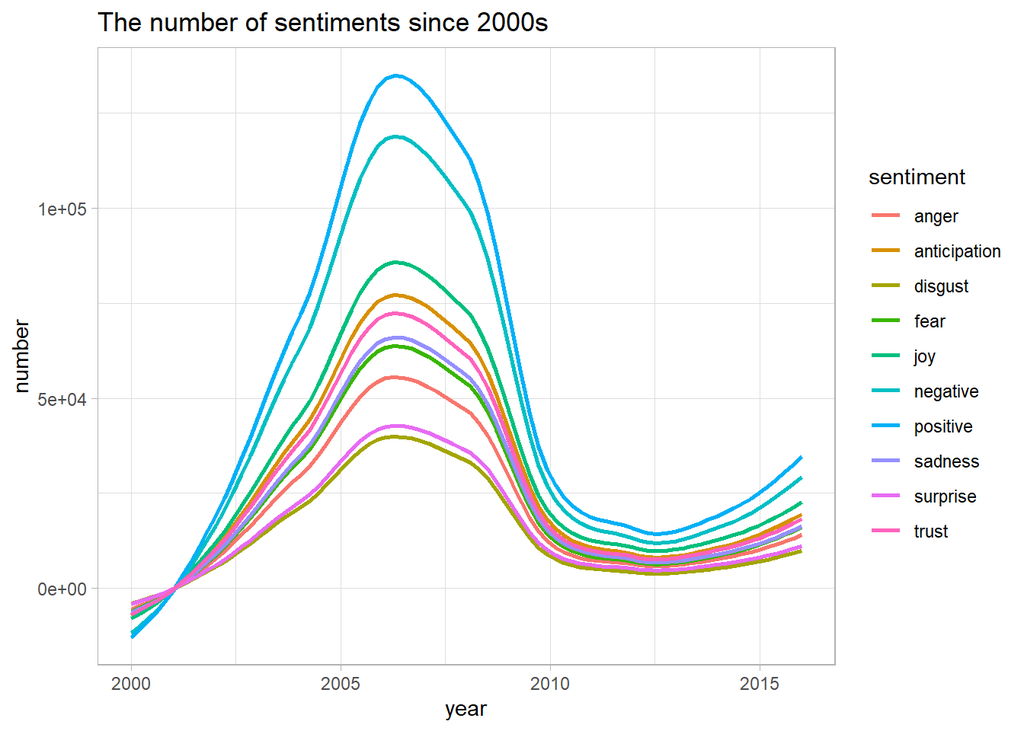

As is shown in the smooth plot, positive and negative are the most two popluar emotions, which are Rock music focused on. Besides,in order to have a better review of people’s preference, I divide the past 50 years into 5 different time periods, and see which sentiments people favored most during that time.

**Plot of sentiment and time period**

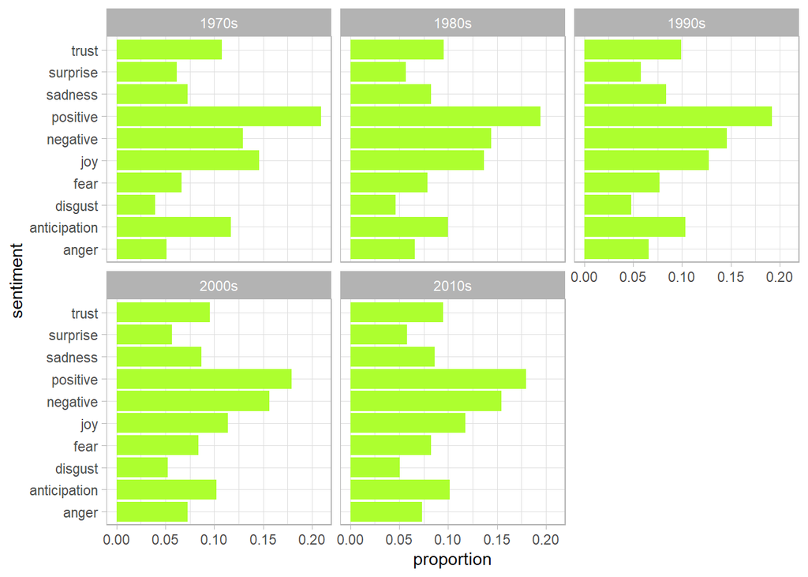

Therefore, no matter which period, positive and negative emotions are still popular by people, which explains the reason that Rock never out of date with its unique emotional expression. Besides, Rock music is also good at expressing all kinds of sentiments.

**The distrition of genres in different sentiments**

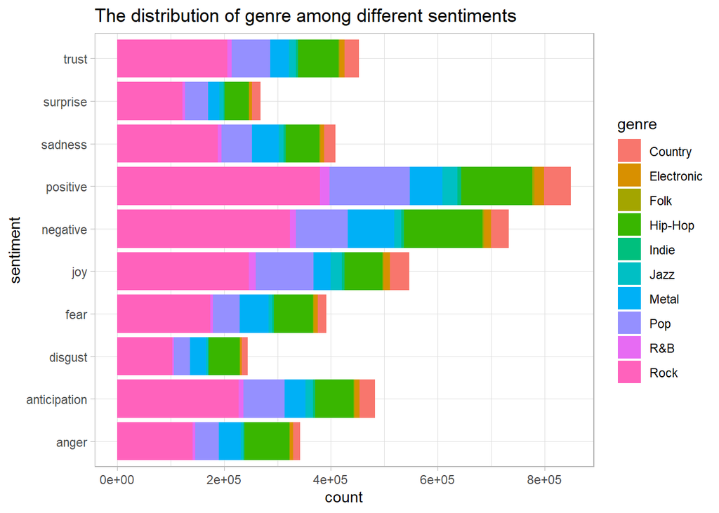

For each sentiment, Rock also occupy a large number of songs to express the sentiment, which means that Rock music is good at expressing all kinds of sentiments. This advantage also contributes to the popularity of Rock.

### Summary

Rock music has been popular and not out of date for past 50 years. By sentiment analysis, this phenomenon results from its unique emotional expression that people prefer for a long time and its involvement in all kinds of sentiments.

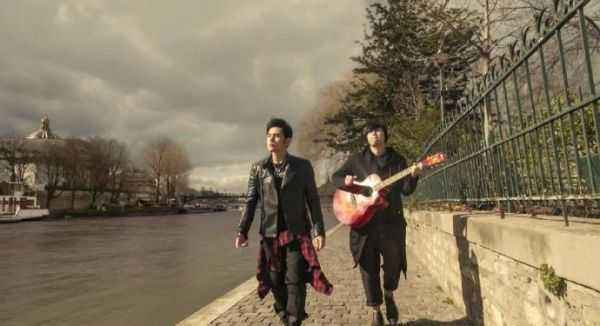

### Reference

1. image1: https://www.google.com.hk/imgres?imgurl=https%3A%2F%2Fi.ytimg.com%2Fvi%2FHK7SPnGSxLM%2Fmaxresdefault.jpg&imgrefurl=https%3A%2F%2Fwww.youtube.com%2Fwatch%3Fv%3DHK7SPnGSxLM&tbnid=0oVZSFFOnpdFFM&vet=12ahUKEwi95aDIrrbnAhVfQDABHQP0ClgQMygDegUIARDWAQ..i&docid=Y9TwiM4pklfOIM&w=1280&h=720&itg=1&q=%E8%AF%B4%E5%A5%BD%E4%B8%8D%E5%93%AD&hl=zh-CN&safe=strict&ved=2ahUKEwi95aDIrrbnAhVfQDABHQP0ClgQMygDegUIARDWAQ
2. image2: https://image.baidu.com/search/detail?ct=503316480&z=0&ipn=d&word=%E6%9D%B0%E4%BC%A6%20%E7%BB%8F%E5%85%B8%20mv&step_word=&hs=0&pn=13&spn=0&di=10340&pi=0&rn=1&tn=baiduimagedetail&is=0%2C0&istype=2&ie=utf-8&oe=utf-8&in=&cl=2&lm=-1&st=-1&cs=3603757715%2C1625779478&os=2883940244%2C2251360015&simid=3203681600%2C3873919620&adpicid=0&lpn=0&ln=1540&fr=&fmq=1580766788020_R&fm=result&ic=&s=undefined&hd=&latest=&copyright=&se=&sme=&tab=0&width=&height=&face=undefined&ist=&jit=&cg=&bdtype=0&oriquery=&objurl=http%3A%2F%2Fimage001.ytexpress.cn%2F20170618%2F270d3065f6a431f03b76e438231eb1be.jpg&fromurl=ippr_z2C%24qAzdH3FAzdH3Fooo_z%26e3Bypjxr6jff_z%26e3BvgAzdH3Fysk2AzdH3Fda80amAzdH3F8099cb_z%26e3Bip4s&gsm=&rpstart=0&rpnum=0&islist=&querylist=&force=undefined
3. ADS_Teaching: https://github.com/TZstatsADS/ADS_Teaching/tree/master/Tutorials